# Train and evaluate models with tidymodels

2022-05-23

# Palmer Penguins Time!!

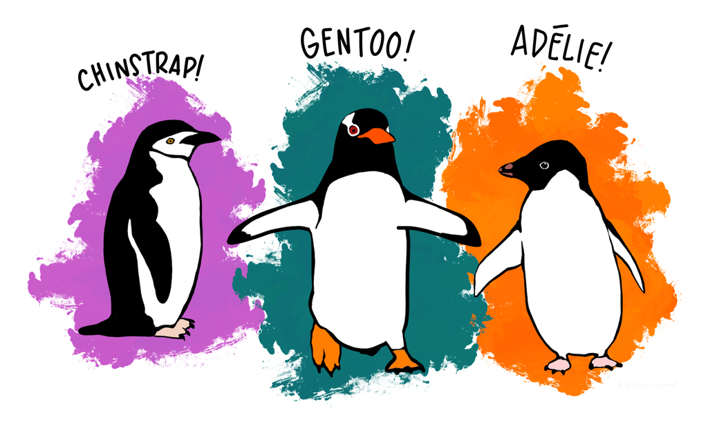

(Figure from @Allison_Horst)

This is part 3 of my TidyModels blogs. The first part[^1] dealt with Random Forests and SVM while the second part[^2] I tried out PCA and UMAP using TidyModels packages.

This time, I will be trying to perform K-Nearest Neighbors and Linear Modelling using TidyModels.

# Loading Datasets, Libraries

```r
library(tidymodels)
library(tidyverse)
data("penguins")
glimpse(penguins)
```

```
## Rows: 344
## Columns: 7
## $ species           <fct> Adelie, Adelie, Adelie, Adelie, Adelie, Adelie, Adel…
## $ island            <fct> Torgersen, Torgersen, Torgersen, Torgersen, Torgerse…
## $ bill_length_mm    <dbl> 39.1, 39.5, 40.3, NA, 36.7, 39.3, 38.9, 39.2, 34.1, …
## $ bill_depth_mm     <dbl> 18.7, 17.4, 18.0, NA, 19.3, 20.6, 17.8, 19.6, 18.1, …
## $ flipper_length_mm <int> 181, 186, 195, NA, 193, 190, 181, 195, 193, 190, 186…
## $ body_mass_g       <int> 3750, 3800, 3250, NA, 3450, 3650, 3625, 4675, 3475, …
## $ sex               <fct> male, female, female, NA, female, male, female, male…
```

```r
penguins <- na.omit(penguins)
```

## Explore data

Exploratory data analysis (EDA) is an important part of the modeling process[^3].I am using the default tidymodels template so will be using the inbuilt EDA performace cells to check the data.

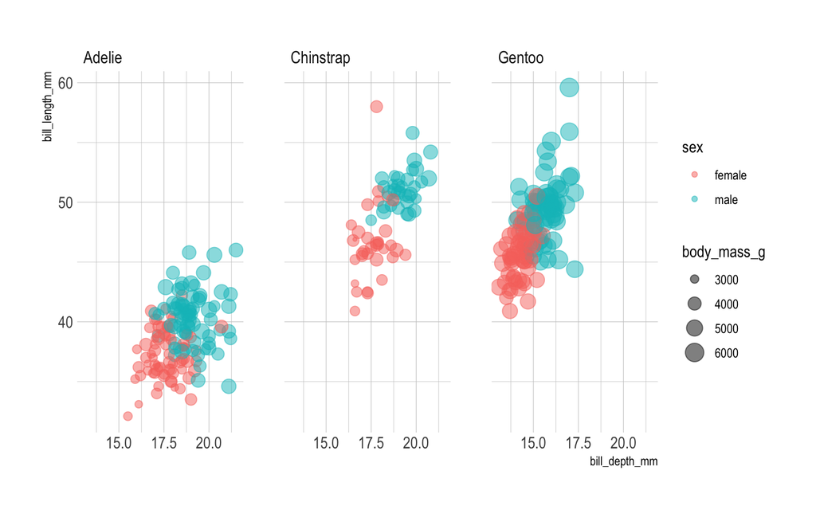

```r
penguins %>%
  ggplot(aes(bill_depth_mm, bill_length_mm, color = sex, size = body_mass_g)) +
  geom_point(alpha = 0.5) +
  facet_wrap(~species) +
  hrbrthemes::theme_ipsum()
```

We see a clear relation between the sex of the penguins with and their bill depth. Further, we can also see a relation between the bill length for each of the species looks difference wrt to the other.

## Build models

Let’s consider how to spend our data budget[^4]:

- create training and testing sets
- create resampling folds from the *training* set

```r
set.seed(123)
penguin_split <- initial_split(penguins, strata = sex)
penguin_train <- training(penguin_split)
penguin_test <- testing(penguin_split)

set.seed(234)
penguin_folds <- vfold_cv(penguin_train, strata = sex)
penguin_folds
```

```
## #  10-fold cross-validation using stratification
## # A tibble: 10 × 2
##    splits           id
##    <list>           <chr>
##  1 <split [223/26]> Fold01
##  2 <split [223/26]> Fold02
##  3 <split [223/26]> Fold03
##  4 <split [224/25]> Fold04
##  5 <split [224/25]> Fold05
##  6 <split [224/25]> Fold06
##  7 <split [225/24]> Fold07
##  8 <split [225/24]> Fold08
##  9 <split [225/24]> Fold09
## 10 <split [225/24]> Fold10
```

Let’s create a model specification[^5] for each model we want to try:

## GLM

```r
glm_spec <-
  logistic_reg() %>%
  set_engine("glm")
```

## KNN

```r
knn_spec <- nearest_neighbor() %>%
  set_engine("kknn") %>%
  set_mode("classification")
```

To set up your modeling code, consider using the parsnip addin[^6] or the usemodels[^7] package.

Now let’s build a model workflow[^8] combining each model specification with a data preprocessor:

```r
penguin_formula <- sex ~ .

glm_wf    <- workflow(penguin_formula, glm_spec)

knn_wf <- workflow(penguin_formula, knn_spec)
```

If your feature engineering needs are more complex than provided by a formula like `sex ~ .`, use a recipe[^9]

## Evaluate models

These models have no tuning parameters so we can evaluate them as they are. [Learn about tuning hyperparameters here[^10]

```r
contrl_preds <- control_resamples(save_pred = TRUE)

glm_rs <- fit_resamples(
  glm_wf,
  resamples = penguin_folds,
  control = contrl_preds
)
```

```
## ! Fold05: preprocessor 1/1, model 1/1: glm.fit: fitted probabilities numerically 0...
```

```r
knn_rs <- fit_resamples(
  knn_wf,
  resamples = penguin_folds,
  control = contrl_preds
)
```

How did these two models compare?

```r
collect_metrics(glm_rs)
```

```
## # A tibble: 2 × 6
##   .metric  .estimator  mean     n std_err .config
##   <chr>    <chr>      <dbl> <int>   <dbl> <chr>
## 1 accuracy binary     0.916    10  0.0173 Preprocessor1_Model1
## 2 roc_auc  binary     0.975    10  0.0105 Preprocessor1_Model1
```

```r
collect_metrics(knn_rs)
```

```
## # A tibble: 2 × 6
##   .metric  .estimator  mean     n std_err .config
##   <chr>    <chr>      <dbl> <int>   <dbl> <chr>
## 1 accuracy binary     0.912    10 0.0132  Preprocessor1_Model1
## 2 roc_auc  binary     0.979    10 0.00697 Preprocessor1_Model1
```

## ROC Curve comparing the two models.

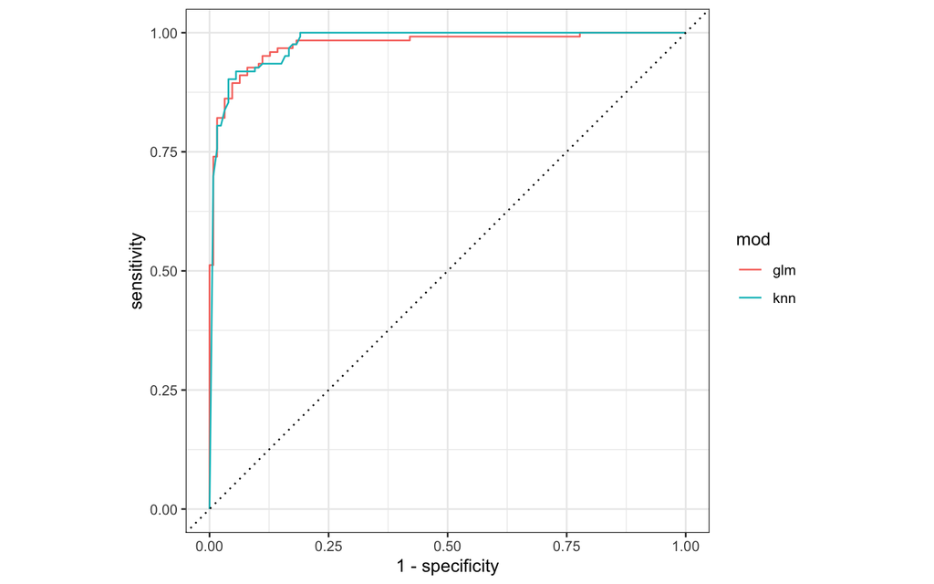

```r
bind_rows(
  collect_predictions(glm_rs) %>%
    mutate(mod = "glm"),
  collect_predictions(knn_rs) %>%
    mutate(mod = "knn")
) %>%
  group_by(mod) %>%
  roc_curve(sex, .pred_female) %>%
  autoplot()
```

These models perform very similarly, so perhaps we would choose the simpler, linear model. The function `last_fit()` *fits* one final time on the training data and *evaluates* on the testing data. This is the first time we have used the testing data.

```r
final_fitted <- last_fit(glm_wf, penguin_split)
collect_metrics(final_fitted)  ## metrics evaluated on the *testing* data
```

```
## # A tibble: 2 × 4
##   .metric  .estimator .estimate .config
##   <chr>    <chr>          <dbl> <chr>
## 1 accuracy binary         0.857 Preprocessor1_Model1
## 2 roc_auc  binary         0.937 Preprocessor1_Model1
```

This object contains a fitted workflow that we can use for prediction.

```r
final_wf <- extract_workflow(final_fitted)
predict(final_wf, penguin_test[59,])
```

```
## # A tibble: 1 × 1
##   .pred_class
##   <fct>
## 1 male
```

```r
penguin_test[59,]
```

```
## # A tibble: 1 × 7
##   species island bill_length_mm bill_depth_mm flipper_length_… body_mass_g sex
##   <fct>   <fct>           <dbl>         <dbl>            <int>       <int> <fct>
## 1 Gentoo  Biscoe           46.5          14.8              217        5200 fema…
```

You can save this fitted `final_wf` object to use later with new data, for example with `readr::write_rds()`.

# Additional Reading:

- https://rstudio-pubs-static.s3.amazonaws.com/749128_01ee1cc430c348438b211f3db0ed6d0a.html
- https://emilhvitfeldt.github.io/ISLR-tidymodels-labs/index.html
- https://www.tidymodels.org/learn/models/
- https://juliasilge.com/blog/palmer-penguins/
[^1]: https://karatsidhu.com/posts/tidymodels-svm-random-forests/
[^2]: https://karatsidhu.com/posts/tidymodels-pca-and-umap/
[^3]: https://www.tmwr.org/software-modeling.html#model-phases
[^4]: https://www.tmwr.org/splitting.html
[^5]: https://www.tmwr.org/models.html
[^6]: https://parsnip.tidymodels.org/reference/parsnip_addin.html
[^7]: https://usemodels.tidymodels.org/
[^8]: https://www.tmwr.org/workflows.html
[^9]: https://www.tidymodels.org/start/recipes/
[^10]: https://www.tidymodels.org/start/tuning/